# Surface Roughness

Jared Stabach, Smithsonian Conservation Biology Institute

20 August, 2019

## Calculate Surface Roughness

We assumed that addax would select inter-dunal depressions. Instead of including the raw SRTM (elevation) data in our models, we created a variable from the raw elevation termed *Surface Roughness*. This variable is the change in elevation range between neighboring pixels. That is, it is the difference between the minimum and maximum values of a cell and its eight surrounding neighbors. Pixels with similar neighborhood values have a low change in elevation range (e.g., flat areas), whereas highly variables neighborhoods have a large change in elevation range (e.g., steep slopes) (Wilson, O’Connell, Brown, Guinan, & Grehan, 2007).

Original data were downloaded from [EarthExplorer](http://earthexplorer.usgs.gov/). Additional information on SRTM can be found [here](https://www2.jpl.nasa.gov/srtm/). I selected a study area window and the data product in the [EarthExplorer](http://earthexplorer.usgs.gov/) application. The data were then bulk downloaded using the USGS [bda](https://earthexplorer.usgs.gov/bulk/) tool.

30-m data often have no data areas (i.e., “holes”). These are errors that must be further processed. To fill these areas, I downloaded an ancillary dataset (the 90-m SRTM gap-filled product (also available on the [EarthExplorer](http://earthexplorer.usgs.gov/) site). In ArcGIS, I used a conditional statement to fill the no data areas with the 90-meter data (con(IsNull(srtm_30m),srtm_90m,srtm_30m). Data were projected to UTM Zone 32 North, WGS84 datum (30-meter spatial resolution).

Reference:

Wilson, M.F.J., O’Connell, B., Brown, C., Guinan, J.C., Grehan, A.J., 2007. Multiscale terrain analysis of multibeam bathymetry data for habitat mapping on the continental slope. Marine Geodesy 30: 3-35.

### Loading Libraries

```r
# Remove everything in memory
rm(list=ls())

# Load raster and rgdal library
library(raster)
library(sp)
library(rgdal)
library(proj4)
```

### Loading Data

Here we load a subset of the full SRTM dataset for our study region. This is simply because the dataset has 30-m resolution and can take a long time to process.

```r
# Load the 30-m SRTM dataset, located in the Data directory
srtm <- raster("Data/srtm_30m")
```

Now load the spatial points dataset (plot locations):

```r
# Load the point data
Sub <- readOGR(dsn="Data", layer="Clipped_Add")
# Look at the file
head(Sub)
```

```
##   Pt_ID       Date YearMonth Id_1        X       Y Addax Dorcas Cornul
## 1    13 2008-12-06    200812   23 825358.1 1773472     0      3      0
## 2    14 2008-12-06    200812   23 830041.8 1776055     0      5      0
## 3    15 2008-12-06    200812   23 835354.5 1779007     0      7      0
## 4    17 2008-12-06    200812   23 840739.0 1781912     0      2      0
## 5    19 2008-12-06    200812   23 845644.1 1784587     0      1      0
## 6    21 2008-12-06    200812   23 850100.0 1787353     0     11      0
##   Stipa1 Stipa2 Human
## 1      1      0     0
## 2      0      0     0
## 3      0      0     1
## 4      1      0     0
## 5      0      0     1
## 6      0      1     0
```

**Questions:**

1. Are these files projected? How would you check?
2. What is the [R](https://cran.r-project.org/) function for re-projecting raster and/or spatial point data files if you needed to?
3. What should you always do when importing spatial data (also good practice for any data you load into [R](https://cran.r-project.org/))?

Plot the results

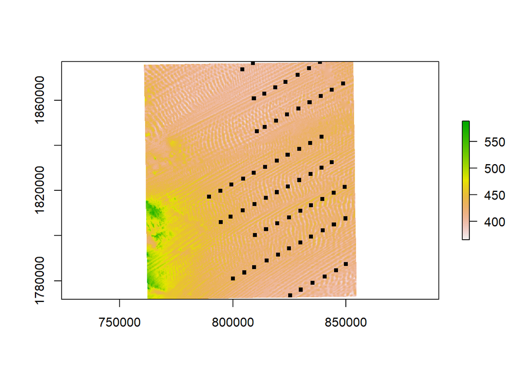

```r
# Plot the result
plot(srtm)
plot(Sub,pch=15,cex=0.7,add=TRUE)
```

### Generate Terrain Variables

Terrain variables can be applied to elevation datasets (digital elevation models). This includes calculating the slope, aspect, Terrain Position Index (TPI), Terrain Ruggedness Index (TRI), and surface roughness. Use `help(terrain)` for additional information.

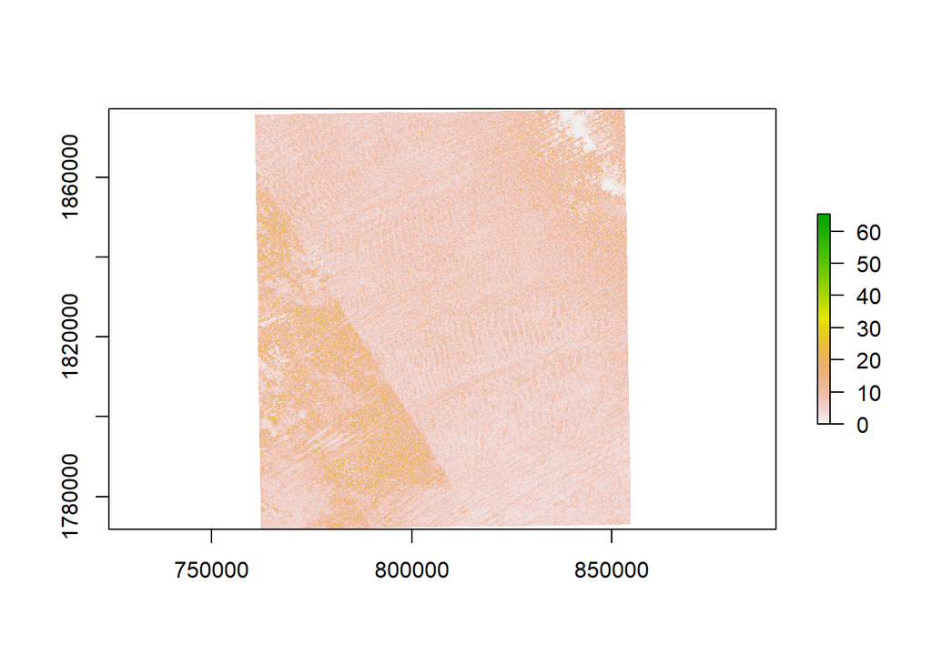

```r
rough <- terrain(srtm,opt='roughness')
plot(rough)
```

### Extract Values

The `extract` command is extremely useful for joining point values from underlying datasets. These values can easily be appended to your existing dataframe and used in analyses.

```r
# Extract SRTM mean values within a 2.5 km buffer of each point location.
Sub$ROUGH <- extract(rough,Sub,method='simple',buffer=2500,fun=mean)

# How is this different than just extracting at the point?
# See `help(extract)` for details about function syntax.
Sub$RGH_PT <- extract(rough,Sub)

# Look at the data
head(Sub)
```

```
##   Pt_ID       Date YearMonth Id_1        X       Y Addax Dorcas Cornul
## 1    13 2008-12-06    200812   23 825358.1 1773472     0      3      0
## 2    14 2008-12-06    200812   23 830041.8 1776055     0      5      0
## 3    15 2008-12-06    200812   23 835354.5 1779007     0      7      0
## 4    17 2008-12-06    200812   23 840739.0 1781912     0      2      0
## 5    19 2008-12-06    200812   23 845644.1 1784587     0      1      0
## 6    21 2008-12-06    200812   23 850100.0 1787353     0     11      0
##   Stipa1 Stipa2 Human    ROUGH   RGH_PT
## 1      1      0     0 3.779610 8.420227
## 2      0      0     0 4.224870 6.208954
## 3      0      0     1 4.340925 2.746216
## 4      1      0     0 4.744831 2.647980
## 5      0      0     1 5.101785 6.040466
## 6      0      1     0 4.952497 2.737762
```